# Preparing reference dataset: Swiss-SEP and Swiss addresses

Author

Lorenz Leuenberger

Published

March 23, 2026

# 1 Introduction

The Swiss neighbourhood index of socioeconomic position (Swiss-SEP) is an area-based measure of socioeconomic status for Switzerland. The Swiss-SEP was constructed by [Panczak et al.](https://doi.org/10.1136/jech-2011-200699) in 2012 and re-validated in [2023](https://doi.org/10.57187/smw.2023.40028). The Swiss-SEP used data from national census data and micro-censuses to assign a socioeconomic position to 1.54 million neighborhoods. The Swiss-SEP is a value between 0-100, where higher values relate to a higher socioeconomic position. Each Swiss-SEP value is linked to a geocode of an address (building) in Switzerland.

## 1.1 Purpose

The purpose of this R script is to link the Swiss-SEP to all Swiss addresses, so that in a second step the clinical data warehouses (CDWs) of the SwissPedHealth project can search for patient addresses and get the linked Swiss-SEP value, see the html document named: “Transforming addresses to Swiss-SEP: Standard operating procedure”. To link the Swiss-SEP to all Swiss addresses geocode information of addresses and Swiss-SEP are used.

This R script does not need to be run at the CDWs. The CDWs receive the reference dataset created with this script separately.

A dataset with all addresses in Switzerland and the corresponding geocodes of the building entrance is available from the [Federal Statistical Office (FSO)](https://www.housing-stat.ch/de/madd/public.html). For the last update in the SwissPedHealth project the building register (Gebäude und Wohnungsregister, GWR) was downloaded on 02.10.2025. The geocodes are given in the (CH1903+ / LV95 Swiss coordinate system)[https://www.swisstopo.admin.ch/de/wissen-fakten/geodaesie-vermessung/koordinaten/schweizer-koordinaten.html]. The Swiss-SEP dataset was provided by the Swiss National Cohort team at the Institute of Social and Preventive Medicine of the University of Bern, after signing a data sharing contract.

```r
library(tidyverse)
library(here)
library(sf)
library(gtsummary)
library(readr)
library(data.table)
library(future.apply)
```

# 2 Import and clean data

Import the Swiss-SEP dataset from the Swiss National Cohort:

```r
swiss_sep <- read.csv(here("data","raw","ssep_open.csv"))
```

Clean the Swiss-SEP dataset:

```r
swiss_sep <- swiss_sep %>%
  rename("geocode_E_sep" = "geox", "geocode_N_sep" = "geoy", "swiss_sep_1" = "ssep1", "swiss_sep_1_decile" = "ssep1_d", "swiss_sep_1_quintile" = "ssep1_q", "swiss_sep_1_tertile" = "ssep1_t", "swiss_sep_2" = "ssep2", "swiss_sep_2_decile" = "ssep2_d", "swiss_sep_2_quintile" = "ssep2_q", "swiss_sep_2_tertile" = "ssep2_t", "swiss_sep_3" = "ssep3", "swiss_sep_3_decile" = "ssep3_d", "swiss_sep_3_quintile" = "ssep3_q", "swiss_sep_3_tertile" = "ssep3_t",)
```

Import the addresses dataset from the FSO:

```r
# ch
addresses <- read_tsv(here("data","raw","ch_02-10-2025","eingang_entree_entrata.csv"))
buildings <- read_tsv(here("data","raw","ch_02-10-2025","gebaeude_batiment_edificio.csv"))
```

Clean the datasets:

```r
addresses <- addresses %>%
  select(EGID, STRNAME, STRNAMK, DEINR, DPLZ4, DPLZNAME, DKODE, DKODN, DOFFADR) %>%
  rename("street" = "STRNAME", "street_short" = "STRNAMK", "number" = "DEINR", "plz" = "DPLZ4", "city" = "DPLZNAME", "geocode_E_address" = "DKODE", "geocode_N_address" = "DKODN", "official_address" = "DOFFADR")


addresses[addresses == ""] <- NA

buildings <- buildings %>%
  select(EGID, GKODE, GKODN) %>%
  rename("geocode_E_building" = "GKODE", "geocode_N_building" = "GKODN")


buildings[buildings == ""] <- NA
```

Some of the building entrances do not have coordinates. Therefore, the building dataset is used to find the coordinates of the buildings for those addresses, instead of the entrance dataset.

```r
addresses <- left_join(addresses, buildings, by = "EGID")

addresses <- addresses %>%
  mutate(geocode_E_address = case_when(is.na(geocode_E_address)==TRUE ~ geocode_E_building,
                                       TRUE ~ geocode_E_address),
         geocode_N_address = case_when(is.na(geocode_N_address)==TRUE ~ geocode_N_building,
                                       TRUE ~ geocode_N_address))

missing_geo <- addresses %>%
  filter((is.na(geocode_E_address)==TRUE | is.na(geocode_N_address)==TRUE))
```

```r
addresses <- addresses %>%
  mutate(geocode_E_address = case_when(EGID == 192021721 ~ 2666314,
                                       EGID == 192032326 ~ 2705862,
                                       EGID == 192034223 ~ 2704159,
                                       EGID == 192037068 ~ 2699713,
                                       EGID == 192040785 ~ 2659330,
                                       EGID == 192041224 ~ 2645701,
                                       EGID == 192045031 ~ 2701782,
                                       EGID == 192045163 ~ 2649155,
                                       EGID == 192045180 ~ 2711737,
                                       EGID == 192045205 ~ 2668599,
                                       EGID == 192045230 ~ 2639526,
                                       EGID == 192045248 ~ 2575586,
                                       EGID == 192045254 ~ 2625845,
                                       EGID == 192045262 ~ 2591553,
                                       EGID == 192045347 ~ 2625845,
                                       EGID == 192045349 ~ 2639262,
                                       EGID == 192045371 ~ 2626471,
                                       EGID == 192045414 ~ 2646240,
                                       EGID == 192045417 ~ 2626609,
                                       EGID == 192045434 ~ 2597951,
                                       TRUE ~ geocode_E_address),
         geocode_N_address = case_when(EGID == 192021721 ~ 1267637,
                                       EGID == 192032326 ~ 1279102,
                                       EGID == 192034223 ~ 1237113,
                                       EGID == 192037068 ~ 1282350,
                                       EGID == 192040785 ~ 1245389,
                                       EGID == 192041224 ~ 1247200,
                                       EGID == 192045031 ~ 1232964,
                                       EGID == 192045163 ~ 1224396,
                                       EGID == 192045180 ~ 1236595,
                                       EGID == 192045205 ~ 1255637,
                                       EGID == 192045230 ~ 1236450,
                                       EGID == 192045248 ~ 1182666,
                                       EGID == 192045254 ~ 1266623,
                                       EGID == 192045262 ~ 1216731,
                                       EGID == 192045347 ~ 1266623,
                                       EGID == 192045349 ~ 1265262,
                                       EGID == 192045371 ~ 1266157,
                                       EGID == 192045414 ~ 1245467,
                                       EGID == 192045417 ~ 1266442,
                                       EGID == 192045434 ~ 1199457,
                                       TRUE ~ geocode_N_address))
```

There are multiple thousands addresses that belong to street names or highway location markers. Only addresses with complete street, plz, and city were kept. Addresses with missing house numbers are not excluded, because there exist correct addresses without any house number.

```r
addresses <- addresses %>%
  filter(is.na(street)==FALSE & is.na(plz)==FALSE & is.na(city)==FALSE & is.na(geocode_E_address)==FALSE)
```

Identify all the characters in the street and city names. Replace “Umlaute” with the written-out spelling and special characters with an empty string.

```r
# street

# street_characters <- addresses %>%
#   select(street) %>%
#   unlist %>%
#   strsplit('') %>%
#   unlist() %>%
#   unique()
#
# street_characters

replace_special_characters <- function(text){

  new_text = gsub('ä', 'ae', text)
  new_text = gsub('á', 'a', new_text)
  new_text = gsub('à', 'a', new_text)
  new_text = gsub('â', 'a', new_text)
  new_text = gsub('Ä', 'AE', new_text)
  new_text = gsub('Á', 'A', new_text)
  new_text = gsub('À', 'A', new_text)
  new_text = gsub('Â', 'A', new_text)
  new_text = gsub('ë', 'e', new_text)
  new_text = gsub('é', 'e', new_text)
  new_text = gsub('è', 'e', new_text)
  new_text = gsub('ê', 'e', new_text)
  new_text = gsub('Ë', 'E', new_text)
  new_text = gsub('É', 'E', new_text)
  new_text = gsub('È', 'E', new_text)
  new_text = gsub('Ê', 'E', new_text)
  new_text = gsub('ï', 'i', new_text)
  new_text = gsub('í', 'i', new_text)
  new_text = gsub('ì', 'i', new_text)
  new_text = gsub('î', 'i', new_text)
  new_text = gsub('Ï', 'I', new_text)
  new_text = gsub('Í', 'I', new_text)
  new_text = gsub('Ì', 'I', new_text)
  new_text = gsub('Î', 'I', new_text)
  new_text = gsub('ö', 'oe', new_text)
  new_text = gsub('ó', 'o', new_text)
  new_text = gsub('ò', 'o', new_text)
  new_text = gsub('ô', 'o', new_text)
  new_text = gsub('Ö', 'OE', new_text)
  new_text = gsub('Ó', 'O', new_text)
  new_text = gsub('Ò', 'O', new_text)
  new_text = gsub('Ô', 'O', new_text)
  new_text = gsub('ü', 'ue', new_text)
  new_text = gsub('ú', 'u', new_text)
  new_text = gsub('ù', 'u', new_text)
  new_text = gsub('û', 'u', new_text)
  new_text = gsub('Ü', 'UE', new_text)
  new_text = gsub('Ú', 'U', new_text)
  new_text = gsub('Ù', 'U', new_text)
  new_text = gsub('Û', 'U', new_text)
  new_text = gsub('ç', "c", new_text)
  new_text = gsub("[.]", '', new_text)
  new_text = gsub(",", "", new_text)
  new_text = gsub(' ', '', new_text)
  new_text = gsub('-', '', new_text)
  new_text = gsub('_', '', new_text)
  new_text = gsub("'", "", new_text)
  new_text = gsub("[+]","", new_text)
  new_text = gsub("[/]","", new_text)
  new_text = gsub("[(]","", new_text)
  new_text = gsub("[)]","", new_text)

  return(new_text)
}

addresses_tbl <- data.table(addresses)

# Use a parallel version of the apply function in the future.apply package

plan(multisession)

# match with the custom functions
addresses_tbl[, street_without_special := future_mapply(replace_special_characters, text = street)]

# street_short

addresses_tbl[, street_short_without_special := future_mapply(replace_special_characters, text = street_short)]


# city

addresses_tbl[, city_without_special := future_mapply(replace_special_characters, text = city)]

addresses <- data.frame(addresses_tbl)
```

Set all characters to lower case. Create a number variable, that ignores added characters after the first number (e.g., “13.a” will be “13”).

```r
addresses <- addresses %>%
  rowwise() %>%
  mutate(street_without_special = tolower(street_without_special),
         street_short_without_special = tolower(street_short_without_special),
         city_without_special = tolower(city_without_special)) %>%
  ungroup()


remove_after_non_digit <- function(text) {
  gsub("\\D.*", "", text)
}

addresses <- addresses %>%
  mutate(street_len = nchar(street_without_special),
         street_short_len = nchar(street_short_without_special),
         number_int = remove_after_non_digit(number),
         number_int = case_when(number_int == "" ~ NA,
                                            TRUE ~ number_int),
         number_int = as.integer(number_int),
         city_len = nchar(city_without_special))

head(addresses)
```

| EGID | street | street_short | number | plz | city | geocode_E_address | geocode_N_address | official_address | geocode_E_building | geocode_N_building | street_without_special | street_short_without_special | city_without_special | street_len | street_short_len | number_int | city_len |
| --- | --- | --- | --- | --- | --- | --- | --- | --- | --- | --- | --- | --- | --- | --- | --- | --- | --- |
| 1 | Grossholzerstrasse | Grossholzerstr. | 20 | 8910 | Affoltern am Albis | 2676523 | 1235843 | 1 | 2676523 | 1235843 | grossholzerstrasse | grossholzerstr | affolternamalbis | 18 | 14 | 20 | 16 |
| 2 | Im Feld | Im Feld | 1 | 8910 | Affoltern am Albis | 2676541 | 1235979 | 0 | 2676541 | 1235979 | imfeld | imfeld | affolternamalbis | 6 | 6 | 1 | 16 |
| 3 | Im Feld | Im Feld | 2 | 8910 | Affoltern am Albis | 2676530 | 1236016 | 1 | 2676524 | 1236012 | imfeld | imfeld | affolternamalbis | 6 | 6 | 2 | 16 |
| 4 | Im Feld | Im Feld | 3 | 8910 | Affoltern am Albis | 2676511 | 1235979 | 1 | 2676513 | 1235974 | imfeld | imfeld | affolternamalbis | 6 | 6 | 3 | 16 |
| 5 | Im Feld | Im Feld | 4 | 8910 | Affoltern am Albis | 2676507 | 1236016 | 1 | 2676502 | 1236014 | imfeld | imfeld | affolternamalbis | 6 | 6 | 4 | 16 |
| 6 | Im Feld | Im Feld | 5 | 8910 | Affoltern am Albis | 2676486 | 1235978 | 1 | 2676487 | 1235974 | imfeld | imfeld | affolternamalbis | 6 | 6 | 5 | 16 |

For addresses that occur multiple times, only the ones that are flagged as official addresses by the FSO are kept:

```r
addresses <- addresses %>%
  rowwise() %>%
  mutate(address_text = paste(street_without_special, number, plz, city_without_special, collapse =" ")) %>%
  ungroup()

addresses <- addresses %>%
  group_by(address_text) %>%
  arrange(desc(official_address)) %>%
  slice(1) %>%
  ungroup() %>%
  select(-official_address, -address_text)


addresses <- tibble::rowid_to_column(addresses, "address_id")
```

# 3 Merge Swiss-SEP to addresses

The two datasets are merged by searching for the nearest geocode of Swiss-SEP to the geocode of the address. The EPSG (European Petroleum Survey Group) code for the Swiss coordinate system is 2056.

```r
addresses_sf <- addresses %>%
  st_as_sf(coords = c("geocode_E_address","geocode_N_address"), remove = FALSE, crs = 2056)

swiss_sep_sf <- swiss_sep %>%
  st_as_sf(coords = c("geocode_E_sep", "geocode_N_sep"), remove = FALSE, crs = 2056)

addresses_and_swiss_sep <- st_join(addresses_sf, swiss_sep_sf, join=st_nearest_feature)

addresses_and_swiss_sep <- addresses_and_swiss_sep %>%
  mutate(distance_address_swiss_sep = sqrt((geocode_E_address - geocode_E_sep)^2 + (geocode_N_address - geocode_N_sep)^2))
```

# 4 Illustration

Load the map of the city of Bern and plot the addresses and Swiss-SEP positions of the Längasse Quartier.

```r
st_layers(here("data", "raw", "swiss-map-vector10_2022_1166_2056.gpkg", "1166", "SMV10_CHLV95LN02.gpkg"))
```

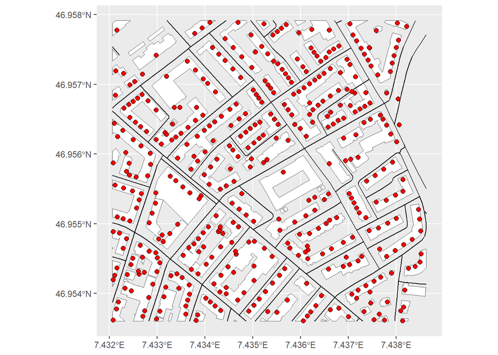

```r
map_bern_buildings <- st_read(here("data", "raw", "swiss-map-vector10_2022_1166_2056.gpkg", "1166", "SMV10_CHLV95LN02.gpkg"), layer = "T48_DKM10_GEBAEUDE")
map_bern_streets <- st_read(here("data", "raw", "swiss-map-vector10_2022_1166_2056.gpkg", "1166", "SMV10_CHLV95LN02.gpkg"), layer = "T45_DKM10_STRASSE")
map_längasse_buildings <- st_crop(map_bern_buildings, xmin = 2599500, xmax = 2600000, ymin = 1200280, ymax = 1200760)
map_längasse_streets <- st_crop(map_bern_streets, xmin = 2599500, xmax = 2600000, ymin = 1200280, ymax = 1200760)

addresses_and_swiss_sep_längasse <- st_crop(addresses_and_swiss_sep, xmin = 2599500, xmax = 2600000, ymin = 1200280, ymax = 1200760)

addresses_längasse <- addresses_and_swiss_sep_längasse %>%
  select(geocode_E_address, geocode_N_address) %>%
  st_drop_geometry() %>%
  st_as_sf(coords = c("geocode_E_address", "geocode_N_address"), remove = FALSE, crs = 2056)

swiss_sep_längasse <- addresses_and_swiss_sep_längasse %>%
  select(geocode_E_sep, geocode_N_sep) %>%
  st_drop_geometry() %>%
  st_as_sf(coords = c("geocode_E_sep", "geocode_N_sep"), remove = FALSE, crs = 2056)

plot_längasse_addresses <- ggplot()+
  geom_sf(data=map_längasse_buildings, fill="white", default_crs = 2056)+
  geom_sf(data=map_längasse_streets)+
  geom_sf(data=addresses_längasse, size = 2, shape = 21, fill="red")

plot_längasse_addresses_swiss_sep <- plot_längasse_addresses+
  geom_sf(data=swiss_sep_längasse, size = 2, shape = 24, fill="blue")

plot_längasse_addresses
```

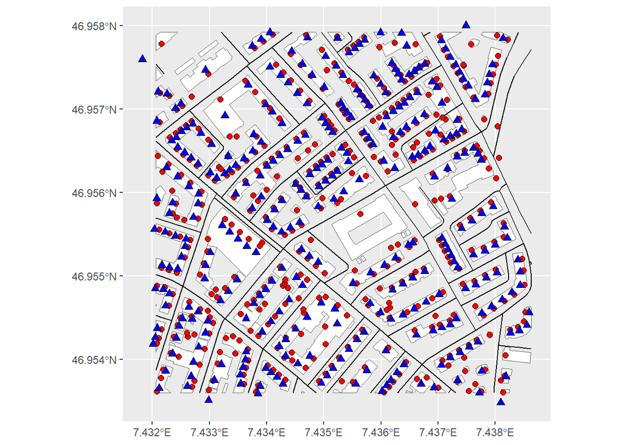

```r
plot_längasse_addresses_swiss_sep
```

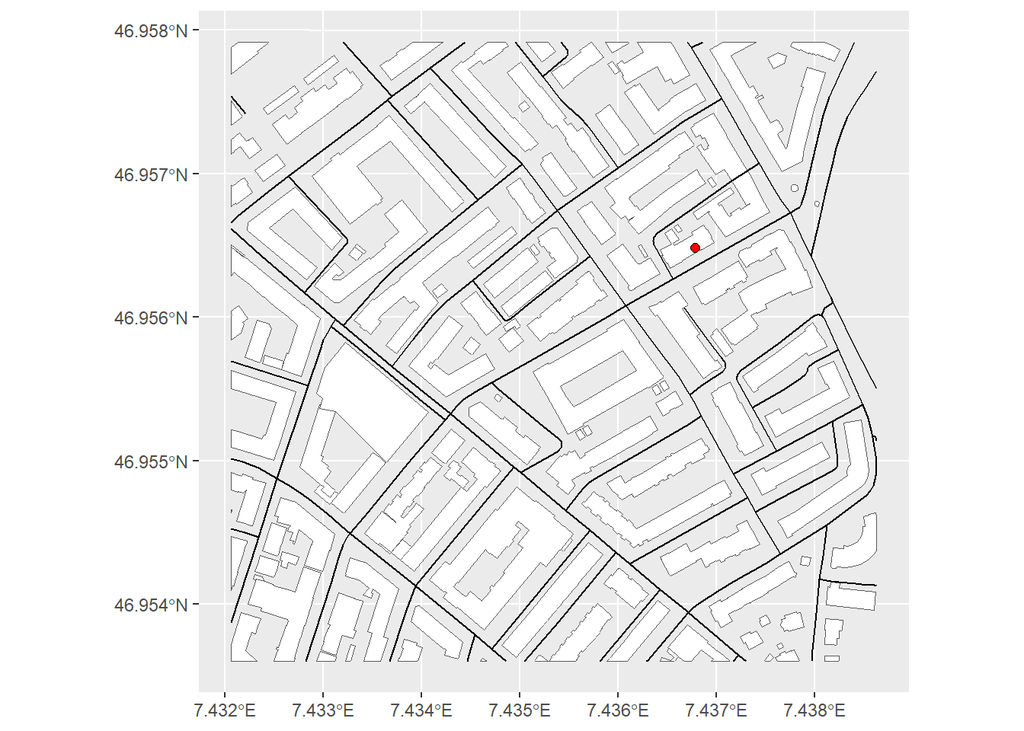

```r
address_mittelstrasse_58 <- addresses_and_swiss_sep_längasse %>%
  filter(street == "Mittelstrasse" & number == "58") %>%
  select(geocode_E_address, geocode_N_address) %>%
  st_drop_geometry() %>%
  st_as_sf(coords = c("geocode_E_address", "geocode_N_address"), remove = FALSE, crs = 2056)

swiss_sep_mittelstrasse_58 <- addresses_and_swiss_sep_längasse %>%
  filter(street == "Mittelstrasse" & number == "58") %>%
  select(geocode_E_sep, geocode_N_sep) %>%
  st_drop_geometry() %>%
  st_as_sf(coords = c("geocode_E_sep", "geocode_N_sep"), remove = FALSE, crs = 2056)

plot_mittelstrasse_58_address <- ggplot()+
  geom_sf(data=map_längasse_buildings, fill="white", default_crs = 2056)+
  geom_sf(data=map_längasse_streets)+
  geom_sf(data=address_mittelstrasse_58, size = 2, shape = 21, fill="red")

plot_mittelstrasse_58_address
```

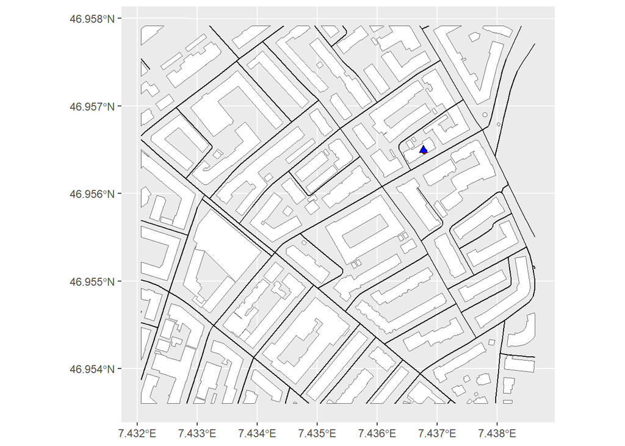

```r
plot_mittelstrasse_58_address_swiss_sep <- plot_mittelstrasse_58_address+
    geom_sf(data=swiss_sep_mittelstrasse_58, size = 2, shape = 24, fill="blue")

plot_mittelstrasse_58_address_swiss_sep
```

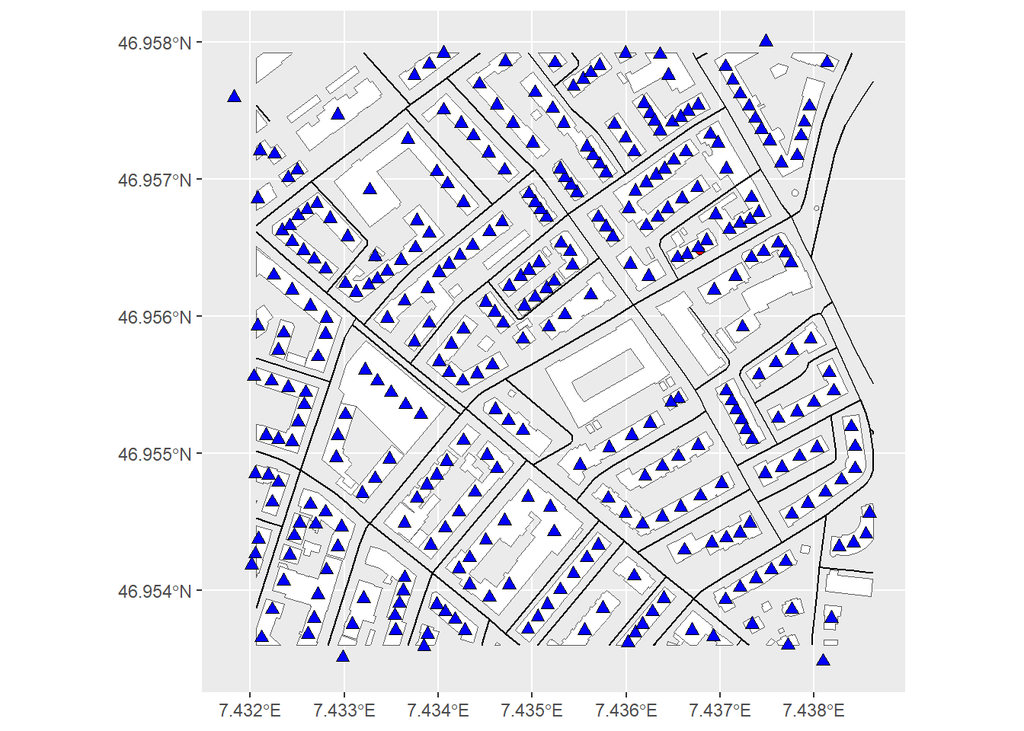

```r
plot_mittelstrasse_58_address_all_swiss_sep <- plot_mittelstrasse_58_address+
    geom_sf(data=swiss_sep_längasse, size = 2, shape = 24, fill="blue")

plot_mittelstrasse_58_address_all_swiss_sep
```

# 5 Save dataset

Create integers of the Swiss-SEP and distance variables as this was described in the concept description for the SPHN RDF Schema to reduce the risk of re-identification.

```r
addresses_and_swiss_sep <- addresses_and_swiss_sep %>%
  st_drop_geometry()

addresses_and_swiss_sep <- addresses_and_swiss_sep |>
  mutate(swiss_sep_1 = as.integer(swiss_sep_1),
         swiss_sep_2 = as.integer(swiss_sep_2),
         swiss_sep_3 = as.integer(swiss_sep_3),
         distance_address_swiss_sep = as.integer(distance_address_swiss_sep))
```

Select the variables and save the dataset after selecting variables:

```r
addresses_and_swiss_sep <- addresses_and_swiss_sep %>%
  select(address_id, street, street_without_special, street_len, street_short, street_short_without_special, street_short_len, number, number_int, plz, city, city_without_special, city_len, swiss_sep_1, swiss_sep_2, swiss_sep_3, distance_address_swiss_sep, geocode_E_address, geocode_N_address) %>%
  rename("address_id_reference" = "address_id", "street_original" = "street","street_reference" = "street_without_special", "street_len_reference" = "street_len", "street_short_original" = "street_short","street_short_reference" = "street_short_without_special", "street_short_len_reference" = "street_short_len", "number_reference" = "number", "number_int_reference" = "number_int", "plz_reference" = "plz", "city_original" = "city","city_reference" = "city_without_special", "city_len_reference" = "city_len")


write.table(addresses_and_swiss_sep, file = here("data","processed","addresses_and_swiss_sep.csv"), sep = ";", row.names = FALSE, quote = FALSE)

saveRDS(addresses_and_swiss_sep, here("data","processed","addresses_and_swiss_sep.rds"))
```

Export the dataset after deleting the Swiss-SEP variables and adding random numbers. This dataset with random numbers is used to demonstrate the next R script: “Transforming addresses to Swiss-SEP: Standard operating procedure”.

```r
addresses_and_swiss_sep_random <- addresses_and_swiss_sep %>%
  mutate(swiss_sep_1 = sample(seq(0:100), size = 3285111, replace = TRUE),
         swiss_sep_2 = swiss_sep_1,
         swiss_sep_3 = swiss_sep_1,
         distance_address_swiss_sep = sample(seq(0:500), size = 3285111, replace = TRUE))


write.table(addresses_and_swiss_sep_random, file = here("data","processed","addresses_and_swiss_sep_random.csv"), sep = ";", row.names = FALSE, quote = FALSE)

saveRDS(addresses_and_swiss_sep_random, here("data","processed","addresses_and_swiss_sep_random.rds"))
```